# PintMF vignette

Morgane Pierre-Jean

2020-04-24

# Introduction

This document shows the results obtained with our method (PintMF) compared to 3 others methods: SNF, MoCluster and intNMF.

We simulate a dataset and we run the methods. We compute the ARI to evaluate the performance of the clustering but also the ROC curve to evaluate the variable selection.

## Useful packages

```r
library(Matrix)
library(tidyverse)
library(PintMF)
library(CrIMMix)
library(future)
library(mclust)
```

```r
library(tidyr)
library(RColorBrewer)
library(future.apply)
library(gplots)
library(gridExtra)
library(tis)
library(stringr)
```

# Methods

## Simulate data with CrIMMix package

We simulate 3 blocs with the same number of individuals (50) but various number of variables. The three blocs mimic various types of omics data with 3 types of distribution (Gaussian, Binary and Beta-like).

```r
set.seed(444)
nclust <- 4
nByclust= c(5, 10, 25, 10)
c_1 <- simulateY(nclust = nclust,  n_byClust = nByclust, J=1000, prop=0.05, noise=1)
c_2 <- simulateY(nclust = nclust,  n_byClust = nByclust, J=500, flavor="binary",
                 params=list(c(p=0.6)), prop=0.1, noise=0.3)

params_beta <- list(c(mean1=-1, mean2=1, sd1=0.5, sd2=0.5))
c_3 <- simulateY(nclust = nclust,  n_byClust = nByclust, J=1000,flavor="beta",
                 params=params_beta, prop=0.1, noise=0.2)
data <- list(c_1$data, c_2$data, c_3$data)

true.clust <- c_1$true.clusters
print(sapply(data,dim))
```

```
#>      [,1] [,2] [,3]
#> [1,]   50   50   50
#> [2,] 1000  500 1000
```

```r
data_names <- c("gaussian", "binary", "beta-like")
names(data) <- data_names
```

## Figures Raw data

Here, we plot the heatmap of each bloc.

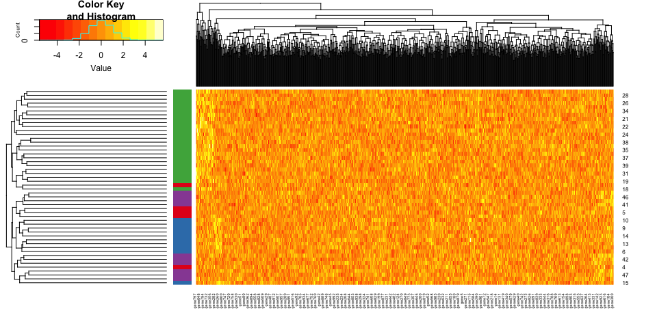

```r
cols.clust <- brewer.pal(4, "Set1")[true.clust %>% as.factor]
data[[1]] %>%  heatmap.2( dendrogram="both", trace="none",Rowv=TRUE, RowSideColors=cols.clust, scale="none")
```

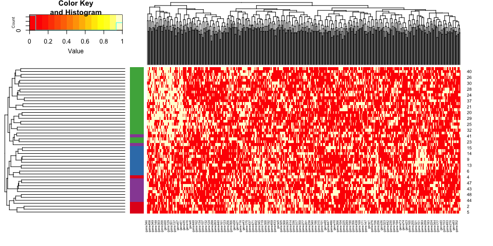

```r
data[[2]] %>%  heatmap.2( dendrogram="both", trace="none",Rowv=TRUE, RowSideColors=cols.clust, scale="none")
```

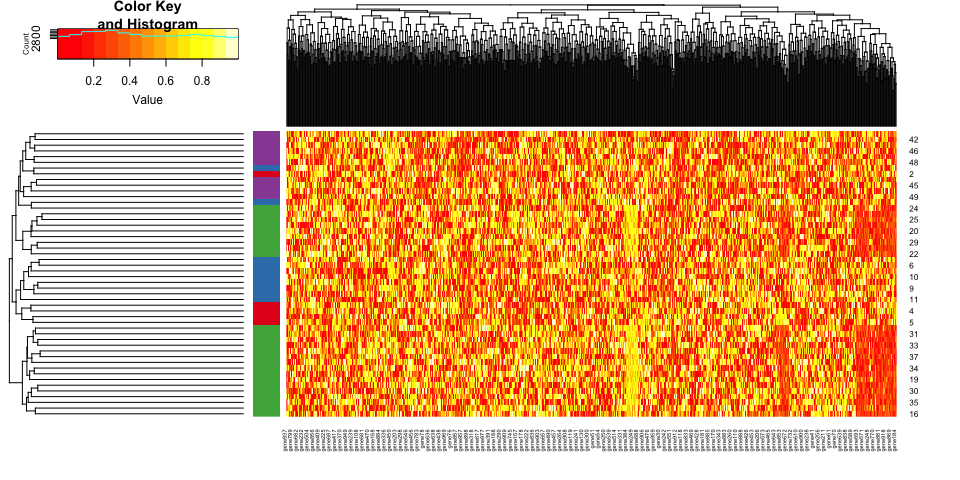

```r
data[[3]] %>%  heatmap.2( dendrogram="both", trace="none",Rowv=TRUE, RowSideColors=cols.clust, scale="none")
```

## Run PintMF

We run PintMF with various number of latent variables.

```r
data_t <- data
data_t[[3]] <- log2(data[[3]]/(1-data[[3]]))
R_p <- future_lapply(2:10, function(p) SolveInt(Y=data_t, p=p, max.it=3, verbose=FALSE, init_flavor="snf", flavor_mod="glmnet"))
```

Here we compute the loss and the BIC in order to select the right number of latent variables.

```r
loss <- sapply(R_p, function (rr){
  W <- rr$W
  l <- sapply(1:length(rr$H), function (ii) {
    h <- rr$H[[ii]]
    y <- data_t[[ii]]
    sum((y-W%*%h)^2)/(nrow(W))
  })
  mean(l)
})
pves <- sapply(R_p, function (rr){
  rr$pve[2]
})
loss_W <- sapply(R_p, function (rr){
  W <- rr$W
  sum(W^2)/ncol(W)
})
```

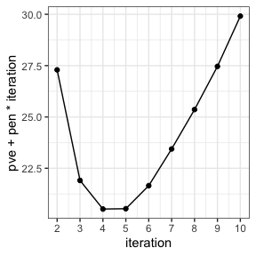

```r
iteration <- 2:10
df_pve <- data.frame(pve=loss_W, iteration=iteration)
pen <- 2*(sapply(data_t, sd) %>% mean)
ggplot(df_pve, aes(x=iteration, y=pve+pen*iteration))+geom_point()+theme_bw()+geom_line()+scale_x_continuous(breaks=1:10)
```

```r
RSS_data_mat <- sapply(R_p, computeLL, Y=data_t)
RSS_data <-  RSS_data_mat %>% t %>% data.frame

BIC <- sapply(seq(from=0.1, to =2, length=5), function (pen) apply(RSS_data_mat, 2, compute_BIC, pen = pen)[1,])
RSS_data <-  RSS_data_mat %>% t %>% data.frame %>% cbind(BIC= BIC) %>% pivot_longer( cols = starts_with("BIC"),names_to = "BIC")
```

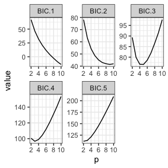

```r
ggplot(data = RSS_data, aes(x = p)) +theme_bw()+geom_line(aes(y = value))+facet_wrap(.~BIC, scale="free")
```

```r
p <- iteration[which.min(RSS_data %>% filter(BIC=="BIC.3") %>% select(value) %>% pull %>% round)]
R <- SolveInt(Y=data_t, p=p, max.it=4, verbose=FALSE, init_flavor="snf", flavor_mod="glmnet")
```

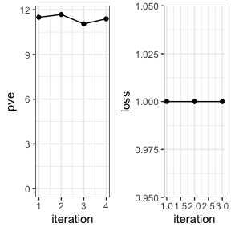

```r
df_pve <- data.frame(pve=R$pve, iteration=1:length(R$pve))
g_pve <- ggplot(df_pve, aes(x=iteration, y=pve))+geom_point()+theme_bw()+geom_line()+ylim(c(0, max(df_pve$pve)))
df_loss <- data.frame(loss=R$loss[-1], iteration=1:length(R$loss[-1]))
g_loss <- ggplot(df_loss, aes(x=iteration, y=loss))+geom_point()+theme_bw()+geom_line()
grid.arrange(g_pve, g_loss, ncol=2)
```

```r
R_moclust <- IntMultiOmics(data_t, method="Mocluster", K=4, k= c(0.4, 0.2, 0.6))
R_intNMF <- IntMultiOmics(data_t, method="intNMF", K=4)
R_SNF <- IntMultiOmics(data_t, method="SNF", K=4)
```

# Performance evaluation

In this section we evaluate the performance of the 4 methods. We first compute the ARI to evaluate the ability of each method to recover the right classification

## Clustering

```r
clust <- R$W %>% dist %>% hclust(method="ward.D2") %>% cutree(4)
clust_moclust <- R_moclust$clust
clust_intNMF <- R_intNMF$clust

clust_snf <- R_SNF$clust

true.clusters <- c_1$true.clusters
cat("my clustering:", adjustedRandIndex(clust, true.clusters), "\n")
```

```
#> my clustering: 1
```

```r
cat("mocluster clustering:", adjustedRandIndex(clust_moclust, true.clusters), "\n")
```

```
#> mocluster clustering: 0.9459305
```

```r
cat("intNMF clustering:", adjustedRandIndex(clust_intNMF, true.clusters), "\n")
```

```
#> intNMF clustering: 0.8935939
```

```r
cat("SNF clustering:", adjustedRandIndex(clust_snf, true.clusters), "\n")
```

```
#> SNF clustering: 1
```

```r
cols <- brewer.pal(4, "Set1")
table(true.clusters, clust)
```

```
#>              clust
#> true.clusters  1  2  3  4
#>            C1  5  0  0  0
#>            C2  0 10  0  0
#>            C3  0  0 25  0
#>            C4  0  0  0 10
```

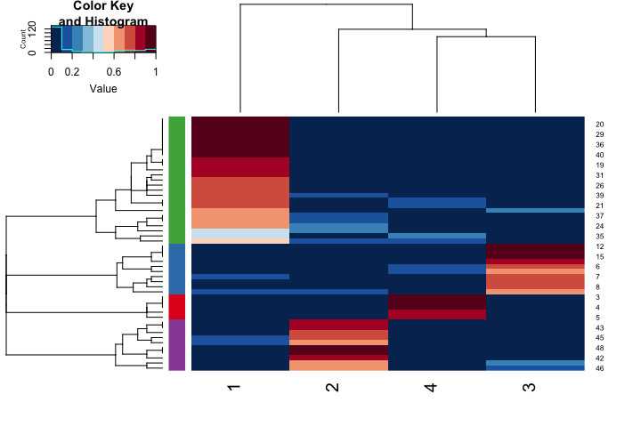

```r
pal <- rev(brewer.pal(10, "RdBu"))
heatmap.2(R$W, scale="none", trace="none",RowSideColors = cols[as.factor(true.clusters)],
                  col = pal)
```

## Variable selection

Then, we evaluate if the methods are able to find the correct variables in the three blocs that drive the clustering.

### TPR and FPR

```r
truth <- lapply(lapply(list(c_1$positive %>% unlist %>% unique,
               c_2$positive%>% unlist %>% unique,
               c_3$positive%>% unlist %>% unique) , stringr::str_remove_all, pattern="gene"), as.numeric)

est_multiom <- lapply(R$H, function (rr) {
  rr%>%
    apply(1,FUN=function(x) which(abs(x)>quantile(abs(x), 0.95))) %>%
    unlist %>%
    unique()
})

ndat <- data %>% length
J <- sapply(data, ncol)


denom_tp <- sapply(truth, length)
mapply(function(e, t, d) (e %>% intersect(t) %>% length)/d, est_multiom, truth, denom_tp)
```

```
#> [1] 0.7554348 0.4525140 0.2742857
```

```r
mapply(function(e, t, d, j) (e %>% setdiff(t) %>% length)/(j-d), est_multiom, truth, denom_tp, J)
```

```
#> [1] 0.05392157 0.02180685 0.13846154
```

```r
a <- R_moclust$fit@loading
test <- rowSums(abs(a))
idx <- which(test!=0)
est_muclust <- test[idx]
est_muclust <- lapply(1:ndat, function (kk){
  idx <- grep(sprintf("dat%s", kk), names(est_muclust))
  regexp <- "[[:digit:]]+"
  gsub(sprintf("_dat%s", kk), "", names(est_muclust)[idx]) %>%
    str_extract(pattern=regexp)
})

mapply(function(e, t, d) (e %>% intersect(t) %>% length)/d, est_muclust, truth, denom_tp)
```

```
#> [1] 0.8695652 0.6592179 0.9228571
```

```r
mapply(function(e, t, d, j) (e %>% setdiff(t) %>% length)/(j-d), est_muclust, truth, denom_tp, J)
```

```
#> [1] 0.5698529 0.1682243 0.8076923
```

### ROC Figures

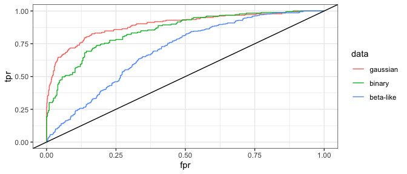

```r
H_transformed <- R$H
H_transformed[[3]] <- apply(H_transformed[[3]], 2, function (hh) hh)
#H_transformed[[1]] <-  apply(H_transformed[[1]], 2, function (hh) hh-mean(hh))
#H_transformed[[2]] <-  apply(H_transformed[[2]], 2, function (hh) hh-mean(hh))

H_coef <- lapply(H_transformed, function (hh) apply(abs(hh), 2, sum))

H_sorted <- lapply(H_coef, order,decreasing = TRUE)
ndat <- length(H_sorted)

TPR_compute <- function(truth, selected_var,nvar=NULL){
  ndat <- length(truth)
  denom_tp <- sapply(truth, length)
  tp <- lapply(1:ndat, function(ii){
    if(is.null(nvar)){nvar= length(selected_var[[ii]])}
    ho <- selected_var[[ii]][1:nvar]
    sapply(1:length(ho), function (tt){
      t <- 1:tt
      tpr <- (ho[t] %>% intersect(truth[[ii]]) %>% length)/denom_tp[ii]
    })
  })
  return(tp)
}

FPR_compute <- function(truth, selected_var, J,nvar=NULL){
  ndat <- length(truth)
  denom_tp <- sapply(truth, length)
  fp <- lapply(1:ndat, function(ii){
    if(is.null(nvar)){nvar= length(selected_var[[ii]])}
    ho <- selected_var[[ii]][1:nvar]
    sapply(1:length(ho), function (tt){
      t <- 1:tt
      fpr <- (ho[t]%>% setdiff(truth[[ii]]) %>% length)/(J[ii]-denom_tp[ii])
    })
  })
  return(fp)
}

TPR_list <- TPR_compute(truth, H_sorted)
FPR_list <- FPR_compute(truth, H_sorted, J)



roc_eval <- list(FPR=FPR_list, TPR=TPR_list)
ROC_df <- do.call(rbind, lapply(1:ndat, function (ii){
  fpr <- roc_eval$FPR[[ii]]
  tpr <- roc_eval$TPR[[ii]]
  return(data.frame(tpr=tpr,fpr=fpr, data=data_names[ii]))
}))
ggplot(ROC_df, aes(x=fpr, y=tpr, color=data, type=data))+geom_line()+scale_x_continuous(limits=c(0,1))+scale_y_continuous(limits=c(0,1))+theme_bw()+geom_abline(slope=1, intercept=0)
```

### Top 10

```r
TPR_compute(truth, H_sorted, 330) %>% sapply( max)
```

```
#> [1] 0.8478261 0.9329609 0.4657143
```

```r
FPR_compute(truth, H_sorted, J, 330) %>%sapply(max)
```

```
#> [1] 0.2132353 0.5077882 0.2569231
```

```r
H_transformed_nmf <- R_intNMF$fit$H
H_transformed_nmf[[3]] <- apply(H_transformed_nmf[[3]], 2, function (hh) hh)
#H_transformed_nmf[[1]] <-  apply(H_transformed_nmf[[1]], 2, function (hh) hh-mean(hh))
#H_transformed_nmf[[2]] <-  apply(H_transformed_nmf[[2]], 2, function (hh) hh-mean(hh))

H_coef_nmf<- lapply(H_transformed_nmf, function (hh) colSums(abs(hh)))

H_sorted_nmf <- lapply(H_coef_nmf, order,decreasing = TRUE)
ndat <- length(H_sorted_nmf)

TPR_list <- TPR_compute(truth, H_sorted_nmf)
FPR_list <- FPR_compute(truth, H_sorted_nmf, J)
data_names <- c("gaussian", "binary", "beta-like")

roc_eval <- list(FPR=FPR_list, TPR=TPR_list)
ROC_df_nmf <- do.call(rbind, lapply(1:ndat, function (ii){
  fpr <- roc_eval$FPR[[ii]]
  tpr <- roc_eval$TPR[[ii]]
  return(data.frame(tpr=tpr,fpr=fpr, data=data_names[ii]))
}))
```

```r
fit <- R_moclust$fit
a <- fit@loading
J <- sapply(fit@data, nrow)
regexp <- "[[:digit:]]+"
ndat <- length(R_moclust$fit@data )

sumA <- rowSums(abs(a))
sumA_order <- sort(sumA, decreasing = TRUE) %>% names
sumA_order <- lapply(1:ndat, function (kk){
  idx <- grep(sprintf("dat%s", kk), sumA_order)
  gsub(sprintf("_dat%s", kk), "", sumA_order[idx]) %>% str_extract(pattern=regexp)
})

TPR_list <- TPR_compute(truth, sumA_order)
FPR_list <- FPR_compute(truth, sumA_order, J)

roc_eval_moclust <- list(FPR=FPR_list, TPR=TPR_list)
ROC_df_moclust <- do.call(rbind, lapply(1:ndat, function (ii){
  fpr <- roc_eval_moclust$FPR[[ii]]
  tpr <- roc_eval_moclust$TPR[[ii]]
  return(data.frame(tpr=tpr,fpr=fpr, data=data_names[ii]))
}))
```

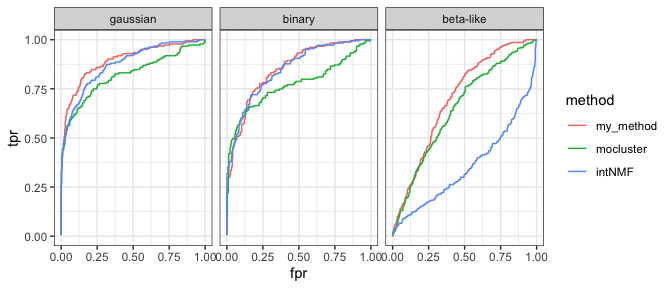

```r
rocs <- rbind(cbind(ROC_df, method="my_method"), cbind(ROC_df_moclust, method="mocluster"), cbind(ROC_df_nmf, method="intNMF"))

ggplot(rocs, aes(x=fpr, y=tpr, color=method))+geom_line()+scale_x_continuous(limits=c(0,1))+scale_y_continuous(limits=c(0,1))+theme_bw()+facet_wrap(.~data)
```

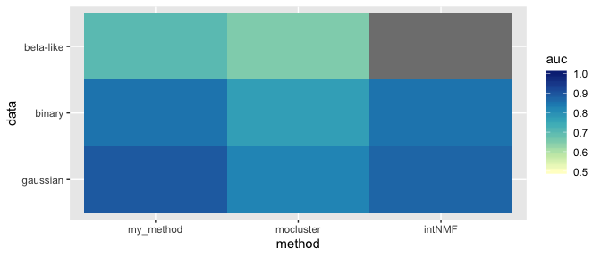

```r
auc <- function (x, y){
  round(sum(lintegrate(c(x,1), c(y,1), xint=c(x,1))),2)
}
rocs %>% group_by(method, data) %>% summarize(auc=auc(fpr, tpr)) %>% ggplot(aes(x=method,y=data, fill=auc))+geom_tile()+ scale_fill_distiller(palette = "YlGnBu", direction=1, limits=c(0.5,1))
```

```r
rocs %>% group_by(data, method) %>% summarize(auc=auc(fpr, tpr))
```

```
#> # A tibble: 9 x 3
#> # Groups:   data [3]
#>   data      method      auc
#>   <fct>     <fct>     <dbl>
#> 1 gaussian  my_method  0.89
#> 2 gaussian  mocluster  0.82
#> 3 gaussian  intNMF     0.87
#> 4 binary    my_method  0.85
#> 5 binary    mocluster  0.77
#> 6 binary    intNMF     0.85
#> 7 beta-like my_method  0.7
#> 8 beta-like mocluster  0.65
#> 9 beta-like intNMF     0.36
```

```r
df_ARI <- data.frame(method=c("my_method", "mocluster", "NMF", "SNF"),
                     ari=c(adjustedRandIndex(clust, true.clusters),
                           adjustedRandIndex(clust_moclust, true.clusters),
                           adjustedRandIndex(clust_intNMF, true.clusters),
                           adjustedRandIndex(clust_snf, true.clusters)))

df_ARI
```

```
#>      method       ari
#> 1 my_method 1.0000000
#> 2 mocluster 0.9459305
#> 3       NMF 0.8935939
#> 4       SNF 1.0000000
```

## Supervised

```r
p <- iteration[which.min(RSS_data %>% filter(BIC=="BIC.3") %>% select(value) %>% pull %>% round)]
group <- true.clust %>% as.factor %>% as.numeric
R_super <- SolveInt(Y=data_t, p=p, max.it=4, group=group, verbose=FALSE, init_flavor="snf", flavor_mod="glmnet")
```

```
#> The clusterings are too different between two iterations: stop here
```

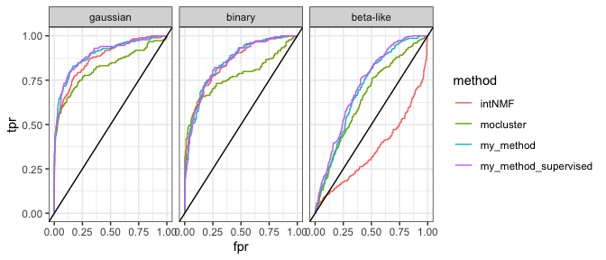

```r
truth <- lapply(lapply(list(c_1$positive %>% unlist %>% unique,
               c_2$positive%>% unlist %>% unique,
               c_3$positive%>% unlist %>% unique) , stringr::str_remove_all, pattern="gene"), as.numeric)

H_transformed <- R_super$H
H_transformed[[3]] <- apply(H_transformed[[3]], 2, function (hh) hh)
#H_transformed[[1]] <-  apply(H_transformed[[1]], 2, function (hh) hh-mean(hh))
#H_transformed[[2]] <-  apply(H_transformed[[2]], 2, function (hh) hh-mean(hh))

H_coef <- lapply(H_transformed, function (hh) apply(abs(hh), 2, sum))

H_sorted <- lapply(H_coef, order,decreasing = TRUE)
ndat <- length(H_sorted)

TPR_compute <- function(truth, selected_var,nvar=NULL){
  ndat <- length(truth)
  denom_tp <- sapply(truth, length)
  tp <- lapply(1:ndat, function(ii){
    if(is.null(nvar)){nvar= length(selected_var[[ii]])}
    ho <- selected_var[[ii]][1:nvar]
    sapply(1:length(ho), function (tt){
      t <- 1:tt
      tpr <- (ho[t] %>% intersect(truth[[ii]]) %>% length)/denom_tp[ii]
    })
  })
  return(tp)
}

FPR_compute <- function(truth, selected_var, J,nvar=NULL){
  ndat <- length(truth)
  denom_tp <- sapply(truth, length)
  fp <- lapply(1:ndat, function(ii){
    if(is.null(nvar)){nvar= length(selected_var[[ii]])}
    ho <- selected_var[[ii]][1:nvar]
    sapply(1:length(ho), function (tt){
      t <- 1:tt
      fpr <- (ho[t]%>% setdiff(truth[[ii]]) %>% length)/(J[ii]-denom_tp[ii])
    })
  })
  return(fp)
}

TPR_list <- TPR_compute(truth, H_sorted)
FPR_list <- FPR_compute(truth, H_sorted, J)



roc_eval <- list(FPR=FPR_list, TPR=TPR_list)
ROC_df <- do.call(rbind, lapply(1:ndat, function (ii){
  fpr <- roc_eval$FPR[[ii]]
  tpr <- roc_eval$TPR[[ii]]
  return(data.frame(tpr=tpr,fpr=fpr, data=data_names[ii]))
})) %>% mutate(method="my_method_supervised")

ggplot(rbind(ROC_df, rocs), aes(x=fpr, y=tpr, color=method, type=method))+geom_line()+scale_x_continuous(limits=c(0,1))+scale_y_continuous(limits=c(0,1))+theme_bw()+geom_abline(slope=1, intercept=0)+facet_wrap(.~data)
```

```r
ROC_df %>% group_by(data) %>% summarize(auc=auc(fpr, tpr)) %>% mutate(method="supervised_pintmf")
```

```
#> # A tibble: 3 x 3
#>   data        auc method
#>   <fct>     <dbl> <chr>
#> 1 gaussian   0.9  supervised_pintmf
#> 2 binary     0.85 supervised_pintmf
#> 3 beta-like  0.72 supervised_pintmf
```

```r
rocs %>% group_by(data, method) %>% summarize(auc=auc(fpr, tpr)) %>% filter(method=="my_method")
```

```
#> # A tibble: 3 x 3
#> # Groups:   data [3]
#>   data      method      auc
#>   <fct>     <fct>     <dbl>
#> 1 gaussian  my_method  0.89
#> 2 binary    my_method  0.85
#> 3 beta-like my_method  0.7
```